# Loan Prediction

## Loan Prediction

Demonstrate various feature selection techniques to model a classification probelem for predicting whether a loan will be approved or not.

### Background

Dream Housing Finance company deals in all kinds of home loans. They have presence across all urban, semi urban and rural areas. Customer first applies for home loan and after that company validates the customer eligibility for loan. Company wants to automate the loan eligibility process (real time) based on customer detail provided while filling online application form.

To automate this process, they have provided a dataset to identify the customers segments that are eligible for loan amount so that they can specifically target these customers.

### Data Dictionary

| Variable | Description |
| --- | --- |
| Loan_ID | Unique Loan ID |
| Gender | Male/ Female |
| Married | Applicant married (Y/N) |
| Dependents | Number of dependents |
| Education | (Graduate/ Under Graduate) |
| Self_Employed | Self employed (Y/N) |
| ApplicantIncome | Applicant income |
| CoapplicantIncome | Coapplicant income |
| LoanAmount | Loan amount in thousands |
| Loan_Amount_Term | Term of loan in months |
| Credit_History | credit history meets guidelines |
| Property_Area | Urban/ Semi Urban/ Rural |
| Loan_Status | (Target) Loan approved (Y/N) |

### Read and Preprocess

```python
import pandas as pd
import numpy as np
import matplotlib as plt

df = pd.read_csv("./data/loan_prediction.csv")

print (df.shape)
df.head()
```

```
(614, 13)
```

|  | Loan_ID | Gender | Married | Dependents | Education | Self_Employed | ApplicantIncome | CoapplicantIncome | LoanAmount | Loan_Amount_Term | Credit_History | Property_Area | Loan_Status |
| --- | --- | --- | --- | --- | --- | --- | --- | --- | --- | --- | --- | --- | --- |
| 0 | LP001002 | Male | No | 0 | Graduate | No | 5849 | 0.0 | NaN | 360.0 | 1.0 | Urban | Y |
| 1 | LP001003 | Male | Yes | 1 | Graduate | No | 4583 | 1508.0 | 128.0 | 360.0 | 1.0 | Rural | N |
| 2 | LP001005 | Male | Yes | 0 | Graduate | Yes | 3000 | 0.0 | 66.0 | 360.0 | 1.0 | Urban | Y |
| 3 | LP001006 | Male | Yes | 0 | Not Graduate | No | 2583 | 2358.0 | 120.0 | 360.0 | 1.0 | Urban | Y |
| 4 | LP001008 | Male | No | 0 | Graduate | No | 6000 | 0.0 | 141.0 | 360.0 | 1.0 | Urban | Y |

```python
df.info()
```

```
<class 'pandas.core.frame.DataFrame'>
RangeIndex: 614 entries, 0 to 613
Data columns (total 13 columns):
 #   Column             Non-Null Count  Dtype
---  ------             --------------  -----
 0   Loan_ID            614 non-null    object
 1   Gender             601 non-null    object
 2   Married            611 non-null    object
 3   Dependents         599 non-null    object
 4   Education          614 non-null    object
 5   Self_Employed      582 non-null    object
 6   ApplicantIncome    614 non-null    int64
 7   CoapplicantIncome  614 non-null    float64
 8   LoanAmount         592 non-null    float64
 9   Loan_Amount_Term   600 non-null    float64
 10  Credit_History     564 non-null    float64
 11  Property_Area      614 non-null    object
 12  Loan_Status        614 non-null    object
dtypes: float64(4), int64(1), object(8)
memory usage: 62.5+ KB
```

Loan_ID is not useful so lets delete it now

```python
df.drop('Loan_ID', axis=1, inplace=True)
```

Number of features now

```python
catFeat = df.select_dtypes(include=['object'])
numFeat = df.select_dtypes(include=['int64', 'float64'])

print(f"Number of categorical features : {len(catFeat.columns)}")
print(f"Number of continuous features : {len(numFeat.columns)}")
```

```
Number of categorical features : 7
Number of continuous features : 5
```

### Statistics of numeric data

```python
df.describe()
```

|  | ApplicantIncome | CoapplicantIncome | LoanAmount | Loan_Amount_Term | Credit_History |
| --- | --- | --- | --- | --- | --- |
| count | 614.000000 | 614.000000 | 592.000000 | 600.00000 | 564.000000 |
| mean | 5403.459283 | 1621.245798 | 146.412162 | 342.00000 | 0.842199 |
| std | 6109.041673 | 2926.248369 | 85.587325 | 65.12041 | 0.364878 |
| min | 150.000000 | 0.000000 | 9.000000 | 12.00000 | 0.000000 |
| 25% | 2877.500000 | 0.000000 | 100.000000 | 360.00000 | 1.000000 |
| 50% | 3812.500000 | 1188.500000 | 128.000000 | 360.00000 | 1.000000 |
| 75% | 5795.000000 | 2297.250000 | 168.000000 | 360.00000 | 1.000000 |
| max | 81000.000000 | 41667.000000 | 700.000000 | 480.00000 | 1.000000 |

```python
df['Loan_Amount_Term'].value_counts()
```

```
360.0    512
180.0     44
480.0     15
300.0     13
84.0       4
240.0      4
120.0      3
36.0       2
60.0       2
12.0       1
Name: Loan_Amount_Term, dtype: int64
```

- 614 rows. We see some missing values in (LoanAmount, Loan_Amount_Term, Credit_History) as these are less than 614
- We see that ApplicationIncome and CoapplicantIncome is right skewed with a mean > median
- Credit History looks to be a discrete with values of either 0 or 1
- min term month is 12 and max is 480, most are 30 years (360). Loan_Amount_Term is discrete with 10 values

### Check for null, missing values

```python
missing = df[df.isnull().any(axis=1)]
if len(missing) > 0:
   print(f'number of missing values: {len(missing)}\n')

   # missing value counts
   print(df.apply(lambda x: sum(x.isnull()), axis=0) )
```

```
number of missing values: 134

Gender               13
Married               3
Dependents           15
Education             0
Self_Employed        32
ApplicantIncome       0
CoapplicantIncome     0
LoanAmount           22
Loan_Amount_Term     14
Credit_History       50
Property_Area         0
Loan_Status           0
dtype: int64
```

134 records have some missing values in columns (Gender, Married, Dependents, Self_Employed, LoanAmount, Loan_Amount_Term, Credit_History)

### Sample some obervations with missing values

```python
missing.sample(n=5, random_state=1)
```

|  | Gender | Married | Dependents | Education | Self_Employed | ApplicantIncome | CoapplicantIncome | LoanAmount | Loan_Amount_Term | Credit_History | Property_Area | Loan_Status |
| --- | --- | --- | --- | --- | --- | --- | --- | --- | --- | --- | --- | --- |
| 188 | NaN | Yes | 0 | Graduate | Yes | 674 | 5296.0 | 168.0 | 360.0 | 1.0 | Rural | Y |
| 158 | Male | No | 0 | Graduate | NaN | 2980 | 2083.0 | 120.0 | 360.0 | 1.0 | Rural | Y |
| 432 | Male | No | 0 | Graduate | NaN | 12876 | 0.0 | 405.0 | 360.0 | 1.0 | Semiurban | Y |
| 24 | Male | Yes | 1 | Graduate | NaN | 3717 | 2925.0 | 151.0 | 360.0 | NaN | Semiurban | N |
| 313 | Male | Yes | 2 | Graduate | Yes | 5746 | 0.0 | 144.0 | 84.0 | NaN | Rural | Y |

Rather than delete missing values, will use imputation to replace with reasonable guesses for missing data.

- most people are not self employed so for missing values assume No for Self_Employed
- replace Gender, Married, Dependends, Loan_Amount_Term, Credit_History' with the the values that occur most frequently (eg: mode)
- replace missing LoanAmount with median

```python
# replace with most common values
df['Gender'].fillna(df['Gender'].mode()[0], inplace=True)
df['Married'].fillna(df['Married'].mode()[0], inplace=True)
df['Dependents'].fillna(df['Dependents'].mode()[0], inplace=True)
df['Self_Employed'].fillna('No', inplace=True)
df['Loan_Amount_Term'].fillna(df['Loan_Amount_Term'].mode()[0], inplace=True)
df['Credit_History'].fillna(df['Credit_History'].mode()[0], inplace=True)
```

Create a pivot table shows median Loan amount by employment and education

```python
table = df.pivot_table(values='LoanAmount', index='Self_Employed' ,columns='Education', aggfunc=np.median)
table
```

| Education Self_Employed | Graduate | Not Graduate |
| --- | --- | --- |
| No | 130.0 | 113.0 |
| Yes | 157.5 | 130.0 |

```python
# Populate missing LoanAmount values given this pivot table data
def medianLoan(data):
    return table.loc[data['Self_Employed'], data['Education']]

df['LoanAmount'].fillna(df[df['LoanAmount'].isnull()].apply(medianLoan, axis=1), inplace=True)
```

```python
df.isnull().any()
```

```
Gender               False
Married              False
Dependents           False
Education            False
Self_Employed        False
ApplicantIncome      False
CoapplicantIncome    False
LoanAmount           False
Loan_Amount_Term     False
Credit_History       False
Property_Area        False
Loan_Status          False
dtype: bool
```

No more missing values

### Check counts for categorical features

```python
for c in catFeat.columns:
    print(catFeat[c].value_counts(normalize=True), '\n')
```

```
Male      0.813644
Female    0.186356
Name: Gender, dtype: float64

Yes    0.651391
No     0.348609
Name: Married, dtype: float64

0     0.575960
1     0.170284
2     0.168614
3+    0.085142
Name: Dependents, dtype: float64

Graduate        0.781759
Not Graduate    0.218241
Name: Education, dtype: float64

No     0.859107
Yes    0.140893
Name: Self_Employed, dtype: float64

Semiurban    0.379479
Urban        0.328990
Rural        0.291531
Name: Property_Area, dtype: float64

Y    0.687296
N    0.312704
Name: Loan_Status, dtype: float64
```

- majority of applicates are Male and more than 50% are married
- over 50% have 0 dependents with near equal proportions with with 1-2
- most are college graduates and not self employed.
- over twice as many loans were approved versus not approvied

## EDA

### Visualize Income and LoanAmount vs Approved

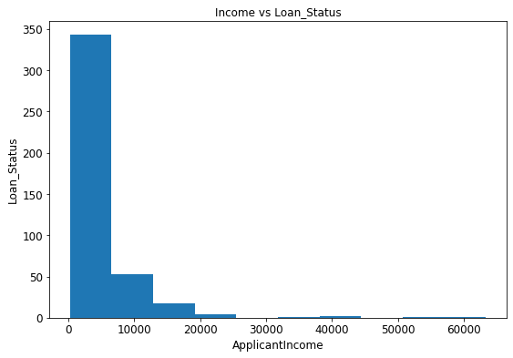

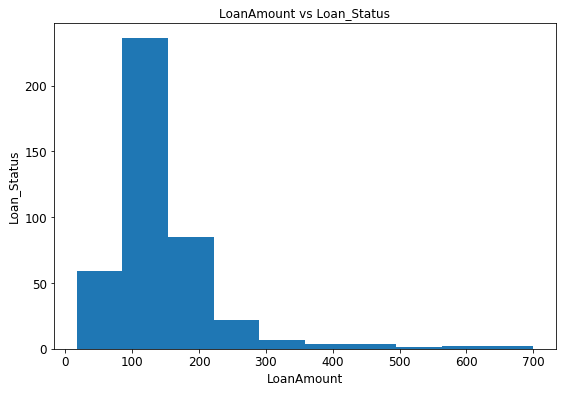

```python
import matplotlib.pyplot as plt

def barPlot(data, aTitle):
    data = data[data['Loan_Status']=='Y']

    ax = data.plot(kind='hist', figsize=(9, 6), title=aTitle, legend=False, fontsize=12)
    ax.set_xlabel(data.columns[0], fontsize=12)
    ax.set_ylabel("Loan_Status", fontsize=12)
    plt.show()

barPlot(df[['ApplicantIncome','Loan_Status']], 'Income vs Loan_Status')

barPlot(df[['LoanAmount','Loan_Status']], 'LoanAmount vs Loan_Status')
```

- Most of the loan approvals were in the lower inome range
- Most of the loan approvals were for Loan Amounts between 100-150

### Visualize Income by Education

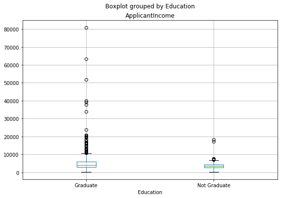

```python
df.boxplot(column='ApplicantIncome', by = 'Education', figsize=(9,6));
```

There is no substantial difference between the mean income of graduate and non-graduates. But there are a higher number of graduates with very high incomes, which appear as outliers

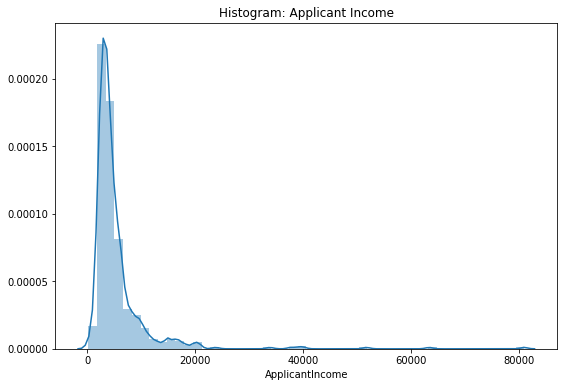

```python
import matplotlib.pyplot as plt
import seaborn as sns

def histDensity(data, aTitle):
    fig = plt.figure(figsize = (9, 6))
    ax = fig.gca()

    sns.distplot(data, kde=True, bins=50, hist=True, ax=ax)
    plt.title(aTitle)
    plt.show();

histDensity(df['ApplicantIncome'], 'Histogram: Applicant Income')
```

Similar analysis for LoanAmount. As a result we will need to log transform income values to create a more normal distribution.

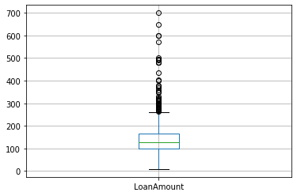

```python
df.boxplot(column='LoanAmount');
```

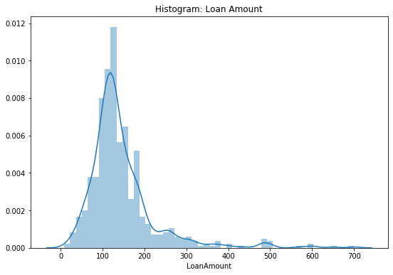

```python
histDensity(df['LoanAmount'], 'Histogram: Loan Amount')
```

Histogram is skewed. Log transform monetary values due to outliers (Eg: some individuals making much more than the average and others making much less

```python
# Add a Log transform
df['LoanAmount_log'] = np.log(df['LoanAmount'])

# drop the old column
df.drop('LoanAmount', axis=1, inplace=True)
```

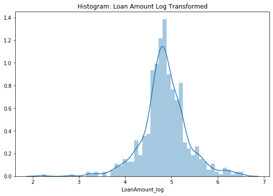

```python
histDensity(df['LoanAmount_log'], 'Histogram: Loan Amount Log Transformed')
```

The log transformed Loan Amounts and Income has a more normal distribution.

Let's add a new total income column which combines two incomes and log transform.

```python
df['TotalIncome'] = df['ApplicantIncome'] + df['CoapplicantIncome']
df['TotalIncome_log'] = np.log(df['TotalIncome'])

# drop old columns
df.drop('ApplicantIncome', axis=1, inplace=True)
df.drop('CoapplicantIncome', axis=1, inplace=True)
df.drop('TotalIncome', axis=1, inplace=True)
```

### Encode categorical

```python
from sklearn.preprocessing import LabelEncoder
le = LabelEncoder()

for c in catFeat.columns:
   df[c] = le.fit_transform(df[c].astype(str))
df.dtypes
```

```
Gender                int64
Married               int64
Dependents            int64
Education             int64
Self_Employed         int64
Loan_Amount_Term    float64
Credit_History      float64
Property_Area         int64
Loan_Status           int64
LoanAmount_log      float64
TotalIncome_log     float64
dtype: object
```

## Feature Selection

- https://scikit-learn.org/stable/modules/feature_selection.html
- https://towardsdatascience.com/feature-selection-techniques-in-machine-learning-with-python-f24e7da3f36e

### Correlation Matrix

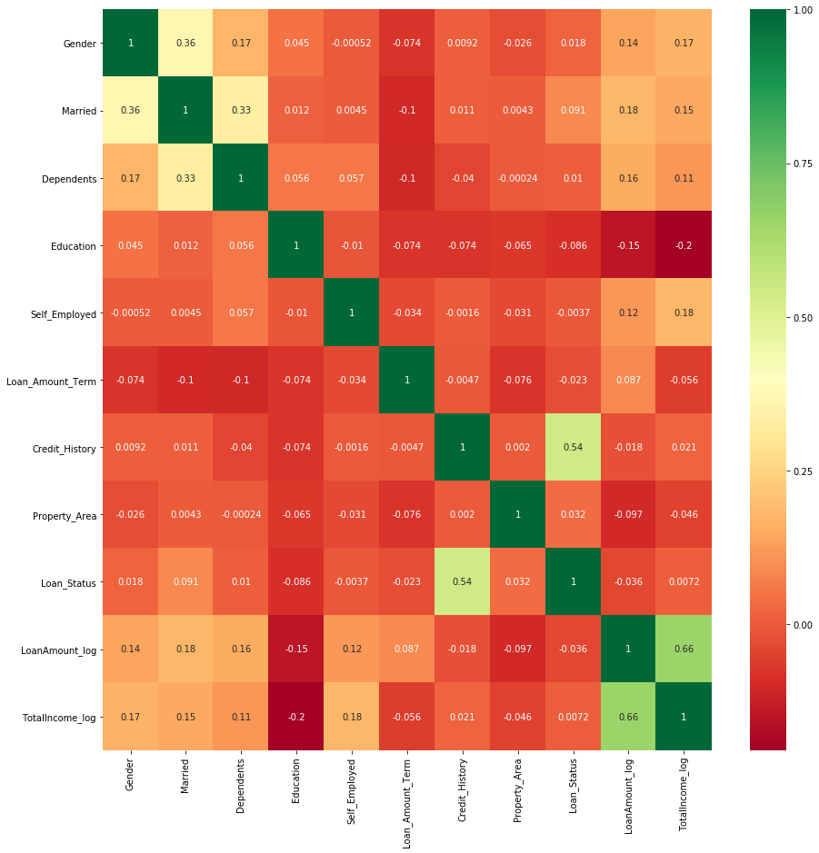

```python
import matplotlib.pyplot as plt
import seaborn as sns

corrmat = df.corr()
top_corr_features = corrmat.index
plt.figure(figsize=(15,15))

#plot heat map
sns.heatmap(df[top_corr_features].corr(),annot=True,cmap="RdYlGn");
```

Of the numeric features, there are strong correlations between

- TotalIncome and LoanAmount (.66)

### categorical features

```python
catFeatures = df[['Gender','Married','Dependents',
                  'Education','Self_Employed','Property_Area',
                  'Loan_Status','Credit_History', 'Loan_Amount_Term']]
catFeatures.head()
```

|  | Gender | Married | Dependents | Education | Self_Employed | Property_Area | Loan_Status | Credit_History | Loan_Amount_Term |
| --- | --- | --- | --- | --- | --- | --- | --- | --- | --- |
| 0 | 1 | 0 | 0 | 0 | 0 | 2 | 1 | 1.0 | 360.0 |
| 1 | 1 | 1 | 1 | 0 | 0 | 0 | 0 | 1.0 | 360.0 |
| 2 | 1 | 1 | 0 | 0 | 1 | 2 | 1 | 1.0 | 360.0 |
| 3 | 1 | 1 | 0 | 1 | 0 | 2 | 1 | 1.0 | 360.0 |
| 4 | 1 | 0 | 0 | 0 | 0 | 2 | 1 | 1.0 | 360.0 |

### What's the relationship between Loan_Status and category variables?

summary_cat function of package researchpy returns a data table as a Pandas DataFrame that includes the counts and percentages of each category.

```python
import researchpy as rp

for c in catFeatures.columns:
    if c=='Loan_Status':
        continue
    print(rp.summary_cat(df[[c, "Loan_Status"]]), '\n')
```

```
      Variable  Outcome  Count  Percent
0       Gender        1    502    81.76
1                     0    112    18.24
2  Loan_Status        1    422    68.73
3                     0    192    31.27

      Variable  Outcome  Count  Percent
0      Married        1    401    65.31
1                     0    213    34.69
2  Loan_Status        1    422    68.73
3                     0    192    31.27

      Variable  Outcome  Count  Percent
0   Dependents        0    360    58.63
1                     1    102    16.61
```

[output cut: 43 more lines]

- more loans are approved than not (68.7% vs 31.2%)
- Of these more applicants are males, married, and the majority 0 dependents.
- 78% are college graduates and 86.6 % are not self employed
- Most loans are for 30 years (85.6%)

## Feature Selection using RandomForest

```python
df.columns
```

```
Index(['Gender', 'Married', 'Dependents', 'Education', 'Self_Employed',
       'Loan_Amount_Term', 'Credit_History', 'Property_Area', 'Loan_Status',
       'LoanAmount_log', 'TotalIncome_log'],
      dtype='object')
```

```python
from sklearn.ensemble import RandomForestClassifier
from sklearn.model_selection import train_test_split
from sklearn.feature_selection import SelectFromModel
from sklearn.metrics import accuracy_score

# All columns
predictors = ['Gender', 'Married', 'Dependents', 'Education', 'Self_Employed',
       'Loan_Amount_Term', 'Credit_History', 'Property_Area',
       'LoanAmount_log', 'TotalIncome_log']


# Split the data into 30% test and 70% training
X_train, X_test, y_train, y_test = train_test_split(df[predictors],
                                                    df['Loan_Status'],
                                                    test_size=0.3, random_state=0)

# Create a random forest classifier for feature importance
clf = RandomForestClassifier(n_estimators=10000, random_state=0, n_jobs=-1)

clf.fit(X_train, y_train)

# Print the name and gini importance of each feature
for feature in zip(predictors, clf.feature_importances_):
    print(feature)
```

```
('Gender', 0.019355089056580378)
('Married', 0.025860518878808948)
('Dependents', 0.058197482869945666)
('Education', 0.02507381818154901)
('Self_Employed', 0.02513451449123142)
('Loan_Amount_Term', 0.032782439146326024)
('Credit_History', 0.26522746550388226)
('Property_Area', 0.05432218619382812)
('LoanAmount_log', 0.22669656711342184)
('TotalIncome_log', 0.2673499185644263)
```

The scores above are the importance scores for each variable. All the importance scores add up to 100%

### Identify And Select Most Important Features

Create a selector object that uses the random forest classifier to identify features that have an importance of more than 0.10

```python
sfm = SelectFromModel(clf, threshold=0.10)

# Train the selector
sfm.fit(X_train, y_train)

# Print the names of the most important features
for feature_list_index in sfm.get_support(indices=True):
    print(predictors[feature_list_index])
```

```
Credit_History
LoanAmount_log
TotalIncome_log
```

### Create A Data Subset With Only the most important Features

compare the accuracy Of the Full Feature Classifier to the Limited Feature Classifier

```python
X_important_train = sfm.transform(X_train)
X_important_test = sfm.transform(X_test)

#Train A New Random Forest Classifier Using Only Most Important Features
clf_important = RandomForestClassifier(n_estimators=10000, random_state=0, n_jobs=-1)

clf_important.fit(X_important_train, y_train)

# Apply The Full Featured Classifier To The Test Data
y_pred = clf.predict(X_test)
print('full model:', accuracy_score(y_test, y_pred))


# Apply The limited Featured Classifier To The Test Data
y_important_pred = clf_important.predict(X_important_test)

print('limited model:', accuracy_score(y_test, y_important_pred))
```

```
full model: 0.7945945945945946
limited model: 0.7621621621621621
```

The original model which contained all features is only slightly more accurate than the ‘limited’ model with only the following features:

- Credit_History, LoanAmount_log, TotalIncome_log

### Chi-Square Feature Selection for categorical

A chi-square test is used to test the independence of two events.

More specifically in feature selection we use it to test whether the occurrence of a specific term and the occurrence of a specific class are independent.

```python
from sklearn.feature_selection import chi2

y = catFeatures ['Loan_Status'].values

catFeatures = catFeatures.drop(['Loan_Status'], axis=1)
x = catFeatures.values

chi_scores = chi2(x, y)
chi_scores
```

```
(array([3.62343084e-02, 1.78242499e+00, 8.59527587e-02, 3.54050246e+00,
        7.28480330e-03, 3.77837464e-01, 2.60058772e+01, 3.77855372e+00]),
 array([8.49032435e-01, 1.81851834e-01, 7.69386856e-01, 5.98873168e-02,
        9.31982300e-01, 5.38762867e-01, 3.40379591e-07, 5.19135142e-02]))
```

The first array represents chi square values and second array represnts p-values. Plotting the p-values

```python
# supporess scientific notation
pd.set_option('display.float_format', lambda x: '%.10f' % x)

p_values = pd.Series(chi_scores[1], index = catFeatures.columns)
p_values.sort_values(ascending = False , inplace = True)
p_values
```

```
Self_Employed      0.9319823003
Gender             0.8490324346
Dependents         0.7693868564
Property_Area      0.5387628674
Married            0.1818518340
Education          0.0598873168
Loan_Amount_Term   0.0519135142
Credit_History     0.0000003404
dtype: float64
```

[figure not shown]

```python
p_values.plot.bar();
```

## SelectKBest for Feature Selection

```python
from sklearn.feature_selection import SelectKBest
from sklearn.feature_selection import f_classif
from sklearn.feature_selection import chi2

selector = SelectKBest(score_func=chi2, # Chi-squared stats of non-negative features for classification tasks
                       k='all')

#y = catFeatures ['Loan_Status'].values
#catFeatures = catFeatures.drop(['Loan_Status'], axis=1)
#x = catFeatures.values

# apply feature selection
x_selected = selector.fit_transform(x, y)

print(x_selected.shape)
print('feature scores: ', selector.scores_,)
print('feature p-values scores:',  selector.pvalues_)
```

```
(614, 8)
feature scores:  [3.62343084e-02 1.78242499e+00 8.59527587e-02 3.54050246e+00
 7.28480330e-03 3.77837464e-01 2.60058772e+01 3.77855372e+00]
feature p-values scores: [8.49032435e-01 1.81851834e-01 7.69386856e-01 5.98873168e-02
 9.31982300e-01 5.38762867e-01 3.40379591e-07 5.19135142e-02]
```

```python
# Get F-scores
cols = selector.get_support(indices=True)

fscores = selector.scores_[cols]

names = catFeatures.iloc[:, cols]
names_scores = list(zip(names, fscores))

ns_df = pd.DataFrame(data = names_scores, columns=['Feature', 'F_Scores'])

#sort
ns_df_sorted = ns_df.sort_values(['F_Scores', 'Feature'], ascending = [False, True])
print(ns_df_sorted)
```

```
            Feature      F_Scores
6    Credit_History 26.0058771534
7  Loan_Amount_Term  3.7785537247
3         Education  3.5405024640
1           Married  1.7824249851
5     Property_Area  0.3778374638
2        Dependents  0.0859527587
0            Gender  0.0362343084
4     Self_Employed  0.0072848033
```

### numeric features

```python
numFeatures = df.drop(['Gender','Married','Dependents','Education','Self_Employed','Property_Area',
                     # 'ApplicantIncome', 'CoapplicantIncome', 'LoanAmount', 'TotalIncome',
                      'Credit_History', 'Loan_Amount_Term'], axis=1)
numFeatures.head()
```

|  | Loan_Status | LoanAmount_log | TotalIncome_log |
| --- | --- | --- | --- |
| 0 | 1 | 4.8675344505 | 8.6740259854 |
| 1 | 0 | 4.8520302639 | 8.7145675508 |
| 2 | 1 | 4.1896547420 | 8.0063675677 |
| 3 | 1 | 4.7874917428 | 8.5053230188 |
| 4 | 1 | 4.9487598904 | 8.6995147482 |

```python
selector = SelectKBest(score_func=f_classif, #ANOVA F-value between label/feature for classification tasks.
                       k='all')

y = numFeatures ['Loan_Status'].values

numFeatures = numFeatures.drop(['Loan_Status'], axis=1)
x = numFeatures.values

x_selected = selector.fit_transform(x, y)

print(x_selected.shape)
print('feature scores: ', selector.scores_,)
print('feature p-values scores:',  selector.pvalues_)
print()

# print F scores
cols = selector.get_support(indices=True)
fscores = selector.scores_[cols]

names = numFeatures.iloc[:, cols]
names_scores = list(zip(names, fscores))

ns_df = pd.DataFrame(data = names_scores, columns=['Feat_names', 'F_Scores'])

#Sort the dataframe for better visualization
ns_df_sorted = ns_df.sort_values(['F_Scores', 'Feat_names'], ascending = [False, True])
print(ns_df_sorted)
```

```
(614, 2)
feature scores:  [0.78153755 0.03208211]
feature p-values scores: [0.37701847 0.85790684]

        Feat_names     F_Scores
0   LoanAmount_log 0.7815375450
1  TotalIncome_log 0.0320821131
```

Top numeric features given high F score: LoanAmount_log

```
TotalIncome_log   0.8579068390
LoanAmount_log    0.3770184746
dtype: float64
```

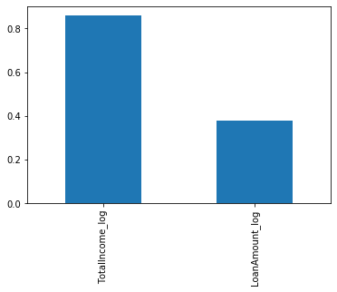

```python
p_values = pd.Series(selector.pvalues_, index = numFeatures.columns)
p_values.sort_values(ascending = False , inplace = True)

p_values.plot.bar();

print(p_values)
```

Combining most important categorical and numeric features:

- Credit_History, Education, LoanAmount_log

This as compared to RandomForest

- Credit_History, LoanAmount_log, TotalIncome_log

## Model Selection via Cross Validation

Models get better as the amount of training data increases. When data is limited, a solution is cross validation. With cross validation, dataset is divided into n splits.

- N-1 split is used for training and the remaining split is used for testing.
- The model runs through the entire dataset n times and at each time, a different split is used for testing.
- Thus, we use all of data points for both training and testing. Cross validation is also useful to measure the performance of a model more accurately, especially on new, previously unseen data points.

There are different methods to split data in cross validation. KFold and StratifiedKFold are commonly used.

- **KFold**: divides the dataset into k folds. If shuffle is False, consecutive folds will be the shifted version of previous fold.If shuffle is True, then the splitting will be random.
- **StratifiedKFold**: in classifications tasks with imbalanced class distributions, we should prefer StratifiedKFold over KFold
- **Cross_val_score**: takes the dataset and applies cross validation to split the data. Then, train a model using the specified estimator/model and measure the performance of the model (scoring parameter).

### Assess different models via cross validation

```python
from sklearn.ensemble import RandomForestClassifier
from sklearn.linear_model import LogisticRegression
from sklearn.ensemble import RandomForestClassifier
from sklearn.naive_bayes import MultinomialNB

from sklearn.model_selection import KFold
from sklearn.model_selection import cross_val_score

# cross validation modeling helper

def classification_model(model, data, predictors, outcome, splits=10):

  kfold = KFold(n_splits=splits, random_state=7, shuffle=True)
  x = data[predictors]
  y = data[outcome]

  scores = cross_val_score(model, x, y, cv=kfold, scoring='accuracy')
  print("  Accuracy: %f (%f)" % (scores.mean(), scores.std()))
  return scores
```

```python
def test_models(predictors, n_splits):
    outcome_var = 'Loan_Status'

    models = [RandomForestClassifier(n_estimators=100),
              MultinomialNB(),
              LogisticRegression(max_iter=500),
    ]

    entries = []

    for model in models:
        model_name = type(model).__name__
        print (model_name)

        scores = classification_model(model, df, predictors, outcome_var,  n_splits)

        for fold_idx, accuracy in enumerate(scores):
            entries.append((model_name, fold_idx, accuracy))


    # plot
    cv_df = pd.DataFrame(entries, columns=['model_name', 'fold_idx', 'accuracy'])
    cv_df.groupby('model_name').accuracy.mean().sort_values()

    sns.boxplot(x='model_name', y='accuracy', data=cv_df)
    sns.stripplot(x='model_name', y='accuracy', data=cv_df,
                  size=8, jitter=True, edgecolor="gray", linewidth=2)
    plt.show()
```

### model using features selected from above

```
RandomForestClassifier
  Accuracy: 0.755671 (0.015037)
MultinomialNB
  Accuracy: 0.687378 (0.040143)
LogisticRegression
  Accuracy: 0.809543 (0.035489)
```

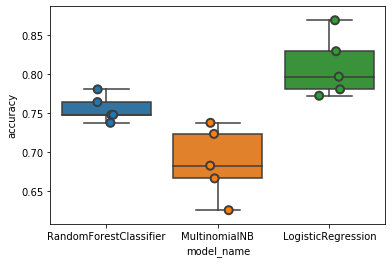

```python
predictors = ['Education', 'Credit_History', 'TotalIncome_log',
              'LoanAmount_log',
             ]
test_models(predictors, 5)
```

LogisticRegression has the highest mean accuracy, followed by RandomForest, then NB

### Model using features selected from Random Forest

```
RandomForestClassifier
  Accuracy: 0.762202 (0.020963)
MultinomialNB
  Accuracy: 0.687378 (0.040143)
LogisticRegression
  Accuracy: 0.809543 (0.035489)
```

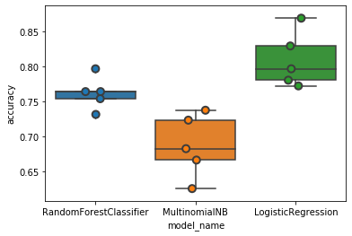

```python
predictors = ['Credit_History', 'LoanAmount_log', 'TotalIncome_log']

test_models(predictors, 5)
```

### Model using all features

```
RandomForestClassifier
  Accuracy: 0.785099 (0.035086)
MultinomialNB
  Accuracy: 0.692256 (0.038446)
LogisticRegression
  Accuracy: 0.809543 (0.035489)
```

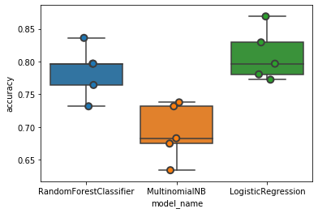

```python
predictors = ['Gender', 'Married', 'Dependents', 'Education', 'Self_Employed',
       'Loan_Amount_Term', 'Credit_History', 'Property_Area', 'TotalIncome_log', 'LoanAmount_log']

test_models(predictors, 5)
```

### Create a final model and make predictions

From the above, LogisticRegression performs the best.

```python
predictors = ['Education', 'Credit_History',
              'LoanAmount_log', 'TotalIncome_log'
             ]

# Split the data into 30% test and 70% training
X_train, X_test, y_train, y_test = train_test_split(df[predictors],
                                                    df['Loan_Status'],
                                                    test_size=0.3, random_state=0)

x = df[predictors]
y = df['Loan_Status']

# train on all the data
lr =  LogisticRegression(max_iter=500)
lr.fit(x, y)

#Make predictions on training set:
predictions = lr.predict(X_test)

#Print accuracy
accuracy = accuracy_score(predictions, y_test)
print ("Accuracy : %s" % "{0:.3%}".format(accuracy))
```

```
Accuracy : 82.703%
```

```python
test = X_test
test['Loan_Status'] = y_test
test
```

|  | Education | Credit_History | LoanAmount_log | TotalIncome_log | Loan_Status |
| --- | --- | --- | --- | --- | --- |
| 454 | 0 | 1.0000000000 | 4.4308167988 | 8.8657351521 | 1 |
| 52 | 0 | 1.0000000000 | 4.7184988713 | 8.3499572720 | 0 |
| 536 | 0 | 1.0000000000 | 5.7807435158 | 9.2142327867 | 1 |
| 469 | 0 | 1.0000000000 | 4.7004803658 | 8.8223221775 | 0 |
| 55 | 0 | 1.0000000000 | 4.5747109785 | 8.2623009418 | 1 |
| ... | ... | ... | ... | ... | ... |
| 242 | 0 | 1.0000000000 | 5.0434251169 | 9.0671626023 | 1 |
| 515 | 0 | 1.0000000000 | 5.0106352941 | 8.8384067471 | 1 |
| 582 | 0 | 1.0000000000 | 3.5835189385 | 8.0602242404 | 1 |
| 225 | 0 | 1.0000000000 | 5.1357984371 | 8.0864102753 | 0 |
| 134 | 0 | 1.0000000000 | 4.6249728133 | 8.4959695550 | 1 |

185 rows × 5 columns

### Predict custom value

with selected features: 'Education', 'Credit_History', 'LoanAmount_log', 'TotalIncome_log

First view approved and not approved records

```python
columns = ['Education', 'TotalIncome_log','LoanAmount_log', 'Loan_Amount_Term',
          'Credit_History', 'Loan_Status']
notapproved = df[df['Loan_Status']==0]
notapproved = notapproved[columns]
notapproved
```

|  | Education | TotalIncome_log | LoanAmount_log | Loan_Amount_Term | Credit_History | Loan_Status |
| --- | --- | --- | --- | --- | --- | --- |
| 1 | 0 | 8.7145675508 | 4.8520302639 | 360.0000000000 | 1.0000000000 | 0 |
| 7 | 0 | 8.6197497797 | 5.0625950330 | 360.0000000000 | 0.0000000000 | 0 |
| 9 | 0 | 10.0778189394 | 5.8550719222 | 360.0000000000 | 1.0000000000 | 0 |
| 13 | 0 | 8.4538273158 | 4.7361984484 | 360.0000000000 | 1.0000000000 | 0 |
| 17 | 0 | 8.1633713165 | 4.3307333403 | 360.0000000000 | 0.0000000000 | 0 |
| ... | ... | ... | ... | ... | ... | ... |
| 596 | 1 | 8.9069353391 | 5.2311086169 | 360.0000000000 | 1.0000000000 | 0 |
| 597 | 0 | 8.0020248182 | 4.4773368145 | 360.0000000000 | 0.0000000000 | 0 |
| 600 | 0 | 10.6473991376 | 5.8579331545 | 180.0000000000 | 1.0000000000 | 0 |
| 605 | 1 | 8.7323045710 | 4.7273878187 | 180.0000000000 | 1.0000000000 | 0 |
| 613 | 0 | 8.4301090845 | 4.8903491282 | 360.0000000000 | 0.0000000000 | 0 |

192 rows × 6 columns

```python
approved = df[df['Loan_Status']==1]
approved = approved[columns]
approved
```

|  | Education | TotalIncome_log | LoanAmount_log | Loan_Amount_Term | Credit_History | Loan_Status |
| --- | --- | --- | --- | --- | --- | --- |
| 0 | 0 | 8.6740259854 | 4.8675344505 | 360.0000000000 | 1.0000000000 | 1 |
| 2 | 0 | 8.0063675677 | 4.1896547420 | 360.0000000000 | 1.0000000000 | 1 |
| 3 | 1 | 8.5053230188 | 4.7874917428 | 360.0000000000 | 1.0000000000 | 1 |
| 4 | 0 | 8.6995147482 | 4.9487598904 | 360.0000000000 | 1.0000000000 | 1 |
| 5 | 0 | 9.1708716281 | 5.5872486584 | 360.0000000000 | 1.0000000000 | 1 |
| ... | ... | ... | ... | ... | ... | ... |
| 608 | 0 | 8.5529463611 | 4.6821312271 | 360.0000000000 | 1.0000000000 | 1 |
| 609 | 0 | 7.9724660160 | 4.2626798770 | 360.0000000000 | 1.0000000000 | 1 |
| 610 | 0 | 8.3202045976 | 3.6888794541 | 180.0000000000 | 1.0000000000 | 1 |
| 611 | 0 | 9.0254555328 | 5.5333894887 | 360.0000000000 | 1.0000000000 | 1 |
| 612 | 0 | 8.9336641787 | 5.2311086169 | 360.0000000000 | 1.0000000000 | 1 |

422 rows × 6 columns

### LoanAmount 350, TotalIncome 100

```python
print (np.log(350), np.log(100))
```

```
5.857933154483459 4.605170185988092
```

```python
Xnew = [[0, 1, 5.8579, 4.60517]]

print(lr.predict(Xnew))
```

```
[1]
```

Prediction is approved: (Graduate and with Credit History)

```python
Xnew = [[0, 0, 5.8579, 4.60517]]

pred = lr.predict(Xnew)
print (pred)
```

```
[0]
```

Prediction is not approved (All same except Credit History is No)

References

- https://scikit-learn.org/stable/modules/feature_selection.html
- https://machinelearningmastery.com/feature-selection-with-real-and-categorical-data/
- https://machinelearningmastery.com/feature-selection-with-categorical-data/
- https://www.kaggle.com/jepsds/feature-selection-using-selectkbest?utm_campaign=News&utm_medium=Community&utm_source=DataCamp.com